# R markdown

## Prediction of house prices

### Intoduction

In this project, the concept of data analysis to predict the house price of Georgia house retail site is used. The house price is one of the sectors that is fundamental in the field of real estate. Real estate agencies always try to value the house according to the age, locations and several factors. In this project, different techniques were used to get insights about the price of the house. Before cleaning the data, it is necessary to explore it.

### Data

The data used in this project was obtained from Kaggle website (https://www.kaggle.com/tornikeonoprishvili/tbilisi-housing-challenge-2020). The site contains two data sets that will need to be combined. To gain insight on the data and perform analyses, the libraries of dplyr, tidyr, ggplot, and modelr were used. These libraries will help determine influential variables on house prices.

### Data processing

```r
# loading data using readr
data1= readr::read_csv('housing_clean_1.csv')
data2=readr::read_csv('housing_clean_2.csv')
head(data1)
```

```
## # A tibble: 6 x 8
##      X1  price space  room bedroom furniture latitude longitude
##   <dbl>  <dbl> <dbl> <dbl>   <dbl>     <dbl>    <dbl>     <dbl>
## 1     0 107100    28     1       1         0     41.7      44.8
## 2     2 257000    72     3       1         1     41.7      44.8
## 3     3 157200    53     2       1         0     41.7      44.8
## 4     4 237200    80     3       2         0     41.7      44.8
## 5     5 158200    60     2       1         0     41.8      44.7
## 6     6 184500    74     2       1         0     41.7      44.8
```

```r
head(data2)
```

```
## # A tibble: 6 x 14
##      X1  price space  room bedroom furniture latitude longitude city_area  floor
##   <dbl>  <dbl> <dbl> <dbl>   <dbl>     <dbl>    <dbl>     <dbl> <chr>      <dbl>
## 1     0 107100    28     1       1         0     41.7      44.8 Saburtalo…    11
## 2     2 257000    72     3       1         1     41.7      44.8 Isani Dis…    15
## 3     3 157200    53     2       1         0     41.7      44.8 Krtsanisi…     2
## 4     4 237200    80     3       2         0     41.7      44.8 Krtsanisi…     3
## 5     5 158200    60     2       1         0     41.8      44.7 Saburtalo…    14
## 6     6 184500    74     2       1         0     41.7      44.8 Krtsanisi…     7
## # … with 4 more variables: max_floor <dbl>, apartment_type <chr>,
## #   renovation_type <chr>, balcony <dbl>
```

## Joining the data

```r
#####***********Transform data using dplyr**********##########

# joining data1 and data2 using dplyr
df= left_join(data1, data2, by= c("X1" = "X1", 'price'='price','space'='space',
                                  'room'='room','bedroom'='bedroom','furniture'='furniture',
                                  'latitude'='latitude','longitude'='longitude'))

# drop X1 variable in df
df= df%>%
  select(-c(X1, latitude, longitude))
# obtain the dimension of the data
dim_desc(df)
```

```
## [1] "[29,209 x 11]"
```

```r
# select the numeric variables in data
ch_data=select_if(df, is.character)
character=select_if(df, is.character)
num_data= select_if(df, is.numeric)
```

```r
# remove outliers
outliers <- boxplot(df$price, plot=FALSE)$out
head(outliers)
```

```
## [1]  889700  724900  724900  988500  823100 1285100
```

```r
length(outliers)
```

```
## [1] 2013
```

```r
df1<- df[-which(df$price %in% outliers),]
```

The price variables had 2013 outliers. The outliers were removed from the data

```r
# 1. Obtain the top 10 most expensive houses using dplyr
top10=head(df%>%
  arrange(desc(price)),10)
top10
```

```
## # A tibble: 10 x 11
##     price space  room bedroom furniture city_area floor max_floor apartment_type
##     <dbl> <dbl> <dbl>   <dbl>     <dbl> <chr>     <dbl>     <dbl> <chr>
##  1 3.30e8    80     2       1         0 Mtatsmin…     2         3 old
##  2 3.31e7   199     3       0         0 Saburtal…     9         9 construction
##  3 1.04e7    67     2       1         0 Saburtal…    10        11 new
##  4 9.89e6   473    12       0         0 Chuguret…     1         1 old
##  5 6.29e6    53     3       2         1 Saburtal…    10        11 new
##  6 5.93e6   150     3       2         1 Other        20        21 new
##  7 5.01e6    40     2       1         0 Saburtal…     9        10 new
##  8 4.94e6   300     5       3         1 Vake Dis…    12        13 new
##  9 4.50e6   165     3       2         1 Vake Dis…    19        24 new
## 10 3.23e6    85     3       2         1 Vake Dis…     1         3 new
## # … with 2 more variables: renovation_type <chr>, balcony <dbl>
```

The data above shows that the top city areas that had the highest house prices was Mtatsminda District, Saburtalo District, Other cities and Vake District. Mtatsminda had the most expensive house.

```r
# get the number of mising values per column
colSums(sapply(df, is.na))
```

```
##           price           space            room         bedroom       furniture
##               0               0               0               0               0
##       city_area           floor       max_floor  apartment_type renovation_type
##               5               5               5              15               5
##         balcony
##               5
```

```r
sum(is.na(df))
```

```
## [1] 40
```

```r
# drop the rows with the missing values
df=na.omit(df)
```

The results above shows that “city area” had 5 missing values, “floor’ had 5 missing values,”apartment type" had 15 missing values, “renovation type and balcony” had 5 missing values. The total number of missing values was 40. The missing values were handled by dropping the rows with missing values.

```r
# convert the variables to categorical
df$city_area=as.factor(df$city_area)
df$apartment_type=as.factor(df$apartment_type)
df$renovation_type=as.factor(df$renovation_type)
```

```r
# data visualization using ggplot
plotHist <- function(data_in, i) {
  data <- data.frame(x=data_in[[i]])
  p <- ggplot(data=df, aes(x=factor(x))) + stat_count() + xlab(colnames(data_in)[i]) + theme_light() +
    theme(axis.text.x = element_text(angle = 90, hjust =1))
  return (p)
}

doPlots <- function(data_in, fun, ii, ncol=3) {
  pp <- list()
  for (i in ii) {
    p <- fun(data_in=data_in, i=i)
    pp <- c(pp, list(p))
  }
  do.call("grid.arrange", c(pp, ncol=ncol))
}
plotDen <- function(data_in, i){
  data <- data.frame(x=data_in[[i]], SalePrice = df$price)
  p <- ggplot(data= df) + geom_line(aes(x = x), stat = 'density', size = 1,alpha = 1.0) +
    xlab(paste0((colnames(data_in)[i]), '\n', 'Skewness: ',round(skewness(data_in[[i]], na.rm = TRUE), 2))) + theme_light()
  return(p)
}
names(character)
```

```
## [1] "city_area"       "apartment_type"  "renovation_type"
```

```r
str(character)
```

```
## tibble[,3] [29,209 × 3] (S3: tbl_df/tbl/data.frame)
##  $ city_area      : chr [1:29209] "Saburtalo District" "Isani District" "Krtsanisi District" "Krtsanisi District" ...
##  $ apartment_type : chr [1:29209] "new" "new" "new" "new" ...
##  $ renovation_type: chr [1:29209] "newly renovated" "newly renovated" "white frame" "white frame" ...
```

```r
character$city_area=as.factor(character$city_area)
character$apartment_type=as.factor(character$apartment_type)
character$renovation_type=as.factor(character$renovation_type)
```

```r
# top 10 price
top_cities = df %>% group_by(city_area) %>%
  summarise(Count = n()) %>%
  arrange(desc(Count)) %>% top_n(20)
```

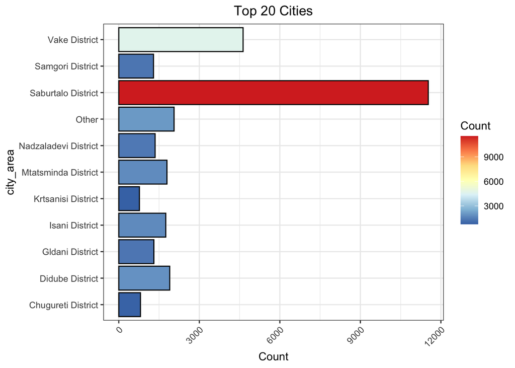

```r
ggplot(data=top_cities,aes(x=city_area,y=Count,fill=Count)) +
  geom_bar(colour='black',stat='identity') +
  theme_bw() +
  ggtitle('Top 20 Cities') +
  theme(axis.text.x = element_text(angle=45,hjust=1),
        plot.title = element_text(hjust=0.5)) +
  scale_fill_distiller(palette = 'RdYlBu') +
  coord_flip() ## coordinate flip bar == > barh
```

```r
mean_ciy=df%>%
  select(price, city_area)%>%
  group_by(city_area)%>%
  summarise(mean= mean(price))%>%
  arrange(desc(mean))
mean_ciy
```

```
## # A tibble: 11 x 2
##    city_area               mean
##    <fct>                  <dbl>
##  1 Mtatsminda District  697573.
##  2 Vake District        435663.
##  3 Chugureti District   283147.
##  4 Krtsanisi District   278111.
##  5 Saburtalo District   275428.
##  6 Other                248172.
##  7 Didube District      213242.
##  8 Isani District       199591.
##  9 Nadzaladevi District 166552.
## 10 Gldani District      140905.
## 11 Samgori District     126682.
```

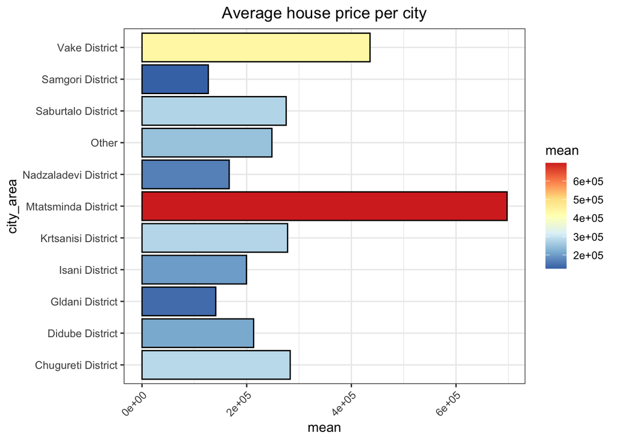

```r
ggplot(data=mean_ciy,aes(x=city_area,y=mean,fill=mean)) +
  geom_bar(colour='black',stat='identity') +
  theme_bw() +
  ggtitle('Average house price per city') +
  theme(axis.text.x = element_text(angle=45,hjust=1),
        plot.title = element_text(hjust=0.5)) +
  scale_fill_distiller(palette = 'RdYlBu') +
  coord_flip() ## coordinate flip bar == > barh
```

The average price of the house in Mtatsminda District was $697572.7. The average house price of Vake District was $435662.7.The average house price of Chugureti District was 283147.The average house price of Krtsanisi District was $278110.7. The average house price of Saburtalo District was 275428. The average house price of Other District was $248172.4. The average house price of Dibude District was $213242.4. The average house price of Isani District was $199591.4. The average house price of Nadzaladevi District was $166551.7 and the average house price of Gidani District was $140905.1.

```r
countdf=df %>%
  select(apartment_type, city_area, price) %>%
  arrange(city_area) %>%
  group_by(city_area, apartment_type) %>%
  summarize(Count = n())
countdf
```

```
## # A tibble: 32 x 3
## # Groups:   city_area [11]
##    city_area          apartment_type Count
##    <fct>              <fct>          <int>
##  1 Chugureti District new              226
##  2 Chugureti District old              582
##  3 Didube District    construction      92
##  4 Didube District    new             1060
##  5 Didube District    old              746
##  6 Gldani District    construction      67
##  7 Gldani District    new              776
##  8 Gldani District    old              465
##  9 Isani District     construction      71
## 10 Isani District     new             1179
## # … with 22 more rows
```

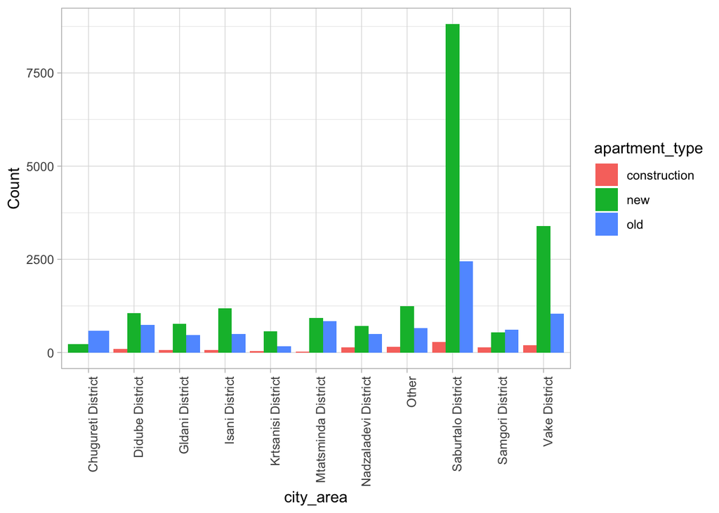

```r
df %>%
  select(apartment_type, city_area, price) %>%
  arrange(city_area) %>%
  group_by(city_area, apartment_type) %>%
  summarize(Count = n()) %>%
  ggplot(aes(city_area, Count)) +
  geom_bar(aes(fill = apartment_type),
           position = 'dodge',
           stat = 'identity') + theme_light() +
  theme(axis.text.x = element_text(angle = 90, hjust =1))
```

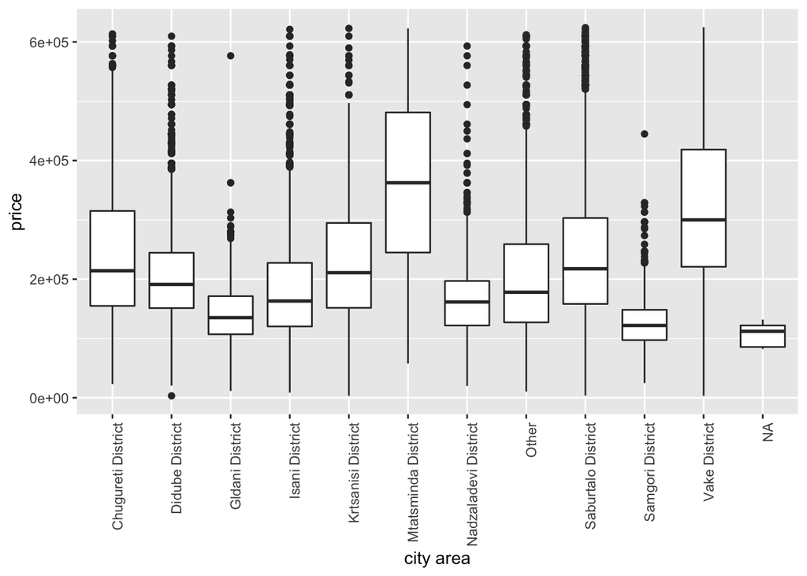

```r
# distribution of the house price for the cities
df1 %>%
  select(city_area, price) %>%
  ggplot(aes(factor(city_area), price)) +
  geom_boxplot() +
  theme(axis.text.x = element_text(angle = 90, hjust =1)) +
  xlab('city area')
```

Mtatsminda District had the highest median house price, followed by Vake District. Samgori District had the lowest median house price.

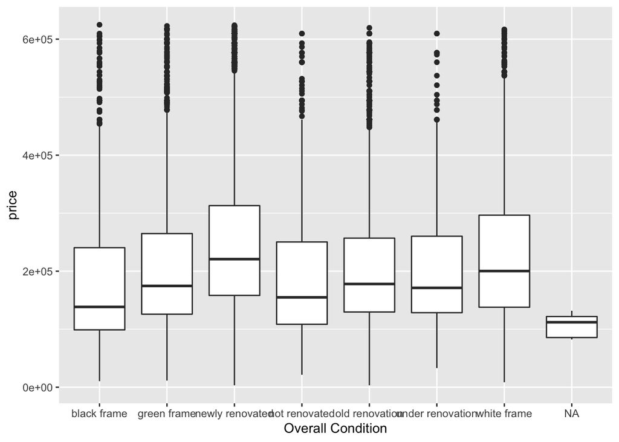

```r
df1 %>%
  select(renovation_type, price) %>%
  ggplot(aes(factor(renovation_type),price)) +
  geom_boxplot() + xlab('Overall Condition')
```

The figure above shows that the newly renovated house were the most expensive, followed by the white frame while the houses that had the lowest price were black framed house.

### Scatterplot

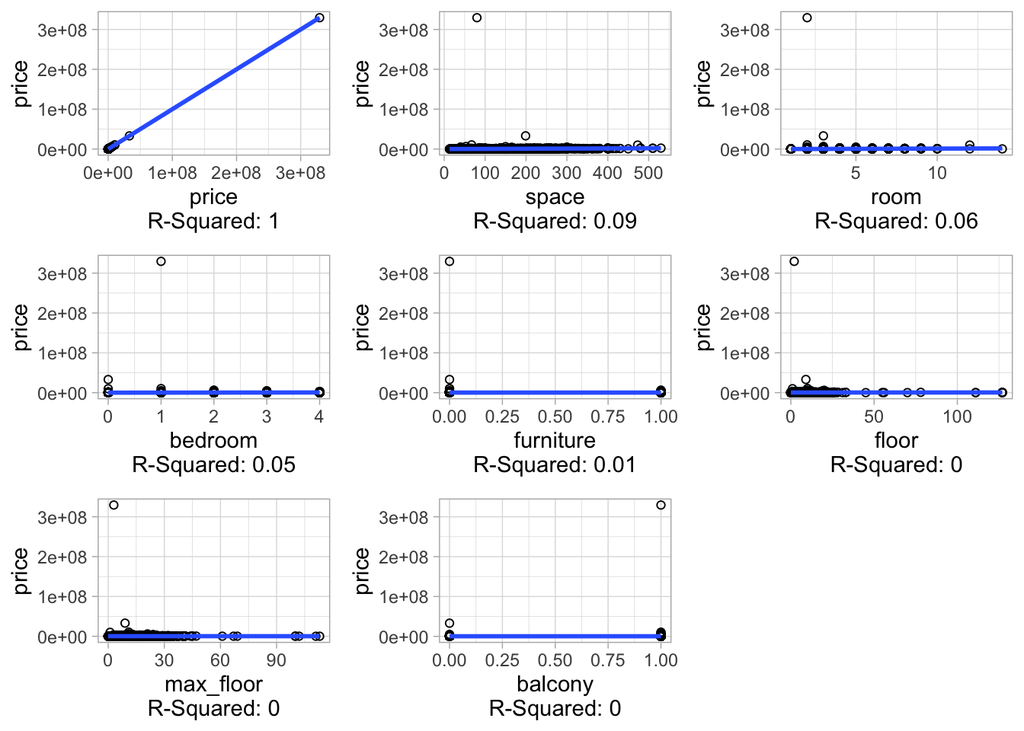

```r
plotCorr <- function(data_in, i){
  data <- data.frame(x = data_in[[i]], price = data_in$price)
  p <- ggplot(data, aes(x = x, y = price)) + geom_point(shape = 1, na.rm = TRUE) + geom_smooth(method = lm ) + xlab(paste0(colnames(data_in)[i], '\n', 'R-Squared: ', round(cor(data_in[[i]], data$price, use = 'complete.obs'), 2))) + theme_light()
  return(suppressWarnings(p))
}


doPlots(num_data, fun = plotCorr, ii = 1:8)
```

```r
mod <- lm(price ~., data = df1)
summary(mod)
```

```
##
## Call:
## lm(formula = price ~ ., data = df1)
##
## Residuals:
##     Min      1Q  Median      3Q     Max
## -566797  -36941   -3698   28663  463879
##
## Coefficients:
##                                  Estimate Std. Error t value Pr(>|t|)
## (Intercept)                      -2268.44    3688.90  -0.615   0.5386
## space                             2573.39      18.56 138.666  < 2e-16 ***
## room                             -8428.62     907.10  -9.292  < 2e-16 ***
## bedroom                           7647.37     936.19   8.169 3.25e-16 ***
## furniture                        15089.90     893.97  16.880  < 2e-16 ***
## city_areaDidube District        -61855.78    2801.30 -22.081  < 2e-16 ***
## city_areaGldani District        -95878.49    2987.48 -32.093  < 2e-16 ***
## city_areaIsani District         -70649.44    2853.34 -24.760  < 2e-16 ***
## city_areaKrtsanisi District     -34240.43    3370.86 -10.158  < 2e-16 ***
## city_areaMtatsminda District     77146.12    2922.72  26.395  < 2e-16 ***
## city_areaNadzaladevi District   -82523.96    2955.40 -27.923  < 2e-16 ***
## city_areaOther                  -47591.78    2785.94 -17.083  < 2e-16 ***
## city_areaSaburtalo District     -38059.56    2473.45 -15.387  < 2e-16 ***
## city_areaSamgori District       -94209.78    2967.33 -31.749  < 2e-16 ***
## city_areaVake District           17099.67    2611.02   6.549 5.89e-11 ***
## floor                             -146.09     102.24  -1.429   0.1530
## max_floor                         1947.23      95.52  20.386  < 2e-16 ***
## apartment_typenew                 2074.06    2176.54   0.953   0.3406
## apartment_typeold               -32173.62    2430.13 -13.239  < 2e-16 ***
## renovation_typegreen frame       48929.78    2624.54  18.643  < 2e-16 ***
## renovation_typenewly renovated   74823.01    2014.30  37.146  < 2e-16 ***
## renovation_typenot renovated     43481.04    3293.05  13.204  < 2e-16 ***
## renovation_typeold renovation    52918.21    2365.11  22.375  < 2e-16 ***
## renovation_typeunder renovation  45665.64    3750.52  12.176  < 2e-16 ***
## renovation_typewhite frame       37037.79    2223.06  16.661  < 2e-16 ***
## balcony                          -2084.07     972.33  -2.143   0.0321 *
## ---
## Signif. codes:  0 '***' 0.001 '**' 0.01 '*' 0.05 '.' 0.1 ' ' 1
##
## Residual standard error: 64410 on 27155 degrees of freedom
##   (15 observations deleted due to missingness)
## Multiple R-squared:  0.7349, Adjusted R-squared:  0.7347
## F-statistic:  3011 on 25 and 27155 DF,  p-value: < 2.2e-16
```

```r
rmse(mod, df1)
```

```
## [1] 64383.89
```

```r
rsquare(mod, df1)
```

```
## [1] 0.734894
```

```r
mae(mod, df1)
```

```
## [1] 45747.16
```

```r
qae(mod, df1)
```

```
##         5%        25%        50%        75%        95%
##   2883.288  14768.781  33054.892  60932.624 134526.701
```

## Conclusion

The most expensive dwellings are newly built or renovated apartments or houses. The ones that are Mtatsminda District on average have higher dwelling prices than the other districts. Even though, independently, independent variables explained a relatively low amount of the variance. However, taken all together, they explain 73,5% of the variance.